# Exploring the BRFSS data

## Setup

### Load packages

```r
library(ggplot2)
library(dplyr)
```

### Load data

Make sure your data and R Markdown files are in the same directory. When loaded your data file will be called `brfss2013`. Delete this note when before you submit your work.

```r
load("~/R Coursera/brfss2013.RData")
```

## Part 1 : Data

# Collection Target

The Data collection is targeted for Adults above 18Years of age. After 2013, Additional Optional Modules have been added for childhood health and wellness indicators, including asthma prevalence for people aged 17 years or younger.

# Data Collection Methodology

The Data is collected on the basis of a questionnaire. The questionnaire is divided into four types

1. **Standard Core Questions** : The portion of the questionnaire that is included each year and must be asked by all states. Each year, the core includes questions about emerging or “late-breaking” health issues. After one year, these questions are either discontinued or incorporated into the fixed core, rotating core, or optional modules.
2. **Rotating Core Questions**: The portion of the questionnaire asked by all states on an every-other year basis.
3. **Optional Modules**: Sets of standardized questions on various topics that each state may select and include in its questionnaire. Once selected, a module must be used in its entirety and asked of all eligible respondents. If an optional module is modified in any way (e.g., if a question is omitted), then the questions will be treated as state-added questions
4. **State-added Questions**: States are encouraged to gather data on additional topics related to their specific health priorities through the use of extra questions they choose to add to their questionnaire. All questions included in the BRFSS are cognitively tested prior to inclusion in the questionnaire.

# Data Collection Rules

Up to 15 calling attempts may be made for each phone number in the sample, depending on state regulations for calling and outcomes of previous calling attempts. Rules on calling attempts are set by the CDC and are provided annually in the Summary Data Quality Reports. In general, surveys are conducted using the following calling occasions

• Conduct 20% of the interviews on weekdays

• Conduct 80% on weeknights and weekends

• Change schedules to accommodate holidays and special events

• Make weekday calls just after the dinner hour

• Make appointment callbacks during hours that are not scheduled for other interviews, generally on weekdays

# Sample Generation

The target sample is generated on the basis of two mediums

**The Landline Sample**

Disproportionate stratified sampling (DSS) has been used for the landline sample since 2003. DDS draws telephone numbers from two strata (lists) that are based on the presumed density of known telephone household numbers.

**The Cellular Sample**

The cellular telephone sample is randomly generated from a sampling frame of confirmed cellular area code and prefix combinations. Cellular telephone respondents are randomly selected with each having equal probability of selection. States complete approximately 20% of their completed interviews with respondents on cell phones.

# Sample Size

The BRFSS goal is to support at least 4,000 interviews per state each year. Factors influencing sample size include the cost involved in data collection for a larger sample and the states’ need for obtaining estimates for subpopulations within states.

# Weighting

Data weighting is an important statistical process that attempts to remove bias in the sample. The BRFSS weighting process includes two steps: design weighting and iterative proportional fitting.

# Collection methods implications on Causality/generalizability

**Generalizability**

In summary, as a large representative random sampling was drawn in both data collection methods, the data for the sample is generalizable to the adult population of the participating states.

Highlights of the data collection methodology

(Source: https://www.cdc.gov/brfss/data_documentation/pdf/userguidejune2013.pdf)

•Disproportionate stratified sampling (DSS) has been used for the landline sample since 2003.

•The cellular telephone sample is randomly generated from a sampling frame of confirmed cellular area code and prefix combinations.

•The BRFSS goal is to support at least 4,000 interviews per state each year.

•Data weighting is an important statistical process that attempts to remove bias in the sample. The BRFSS uses a weighting process includes two steps: design weighting and iterative proportional fitting (also known as “raking” weighting.)

**Causality:**

BRFSS is an ongoing surveillance system. A surveillance system is a series of surveys conducted again and again to monitor long-term trends in public health. It is used to examine public health issues across several years, to track the trends, compare health among groups of people, and determine whether something is improving or worsening for a specific group of people.

A surveillance system is an observational study. Therefore, it won’t be possible to make causal inferences from the data.

## Part 2 : Research questions

**Research Question 1**

Is there any correlation between the general health of a person and a person who has smoked atleast 100 Cigarettes in his lifetime. Furthermore, are there any noticeable differences in this correlation between genders.

As a smoker myself, this research question is really interesting for me to figure out the effects of smoking on health

Variables used :

1. genhlth : General Health
2. smoke100
3. sex : M/F

**Research Question 2**

Is there any correlation between the Average Number of alcoholic drink a respondent has had in the last 30 Days and the Energy level of the respondent in the last 30 Days. Furthermore, is there any noticeable difference in the trend between genders.

This research is quite interesting to me as i am a moderate drinker and would like to know the effects of alcohol on the overall energy level of an individual

Variables Used :

1. qlhlth2 : How Many Days Full Of Energy In Past 30 Days
2. avedrnk2 : Avg Drinks per day in the last 30 days
3. Sex : M/F

**Research Question 3**

Is there any correlation between the consumption of Dark Green Vegetables in the last 30 days and Number of days of poor health(30Days).Furthermore, is there any noticeable difference in the trend between genders.

This research is useful as I consume a combination of Brocolli and Green Beans daily. It would be helpful to know the effects of that on the health of an individual

Variables Used :

1. poorhlth : Number of days of poor health (30 Days)
2. fvgreen : Times Dark Green Vegetables were consumed in the last 30 days
3. Sex : M/F

## Part 3 : Exploratory data analysis

**Research Question 1 :**

```r
res1<-select(brfss2013,genhlth,smoke100,sex) %>% filter(!is.na(genhlth),!is.na(sex),!is.na(smoke100))
res1 %>% group_by(genhlth) %>% summary(count=n())
```

```
##       genhlth       smoke100         sex
##  Excellent: 82734   Yes:214285   Male  :194166
##  Very good:154799   No :260702   Female:280821
##  Good     :145760
##  Fair     : 64609
##  Poor     : 27085
```

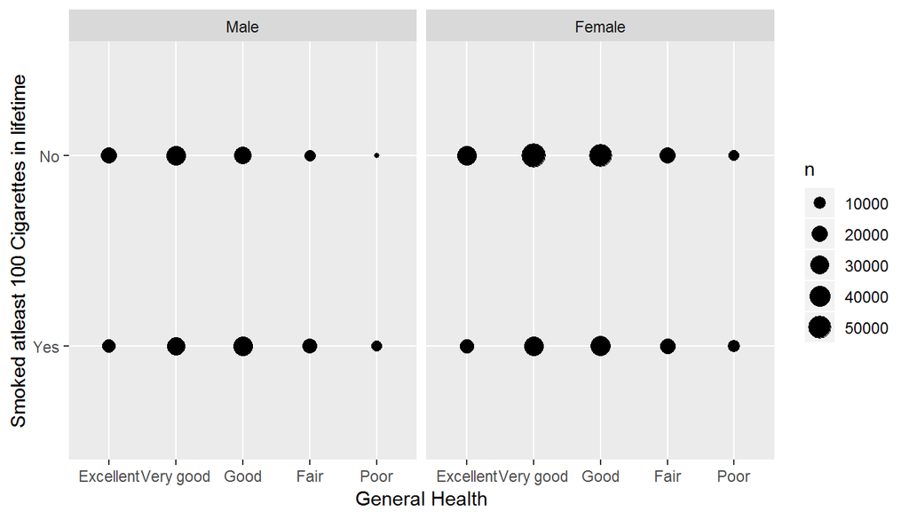

```r
ggplot(data=res1,aes(x=genhlth,y=smoke100,labels(count(smoke100))))+geom_count()+facet_grid(. ~  sex)+xlab("General Health")+ylab("Smoked atleast 100 Cigarettes in lifetime")
```

Both genders are behaving similarly in the observation that People who smoked atleast 100 cigarettes in their lifetime had poorer health compared to people who smoked less than 100 or do not at all.

The number of people who have excellent health is significantly more for people who smoked less than 100 or 0 cigarettes in their lifetime for both the Genders.

**Research Question 2 :**

```r
res2<-brfss2013 %>% select(qlhlth2,avedrnk2,sex) %>% filter(!is.na(qlhlth2),!is.na(avedrnk2),!is.na(sex))
```

```r
res2 %>% group_by(qlhlth2) %>% summary(count=n())
```

```
##     qlhlth2        avedrnk2          sex
##  Min.   : 0.0   Min.   : 1.000   Male  :73
##  1st Qu.: 5.0   1st Qu.: 1.000   Female:80
##  Median :20.0   Median : 2.000
##  Mean   :17.9   Mean   : 2.595
##  3rd Qu.:30.0   3rd Qu.: 3.000
##  Max.   :30.0   Max.   :20.000
```

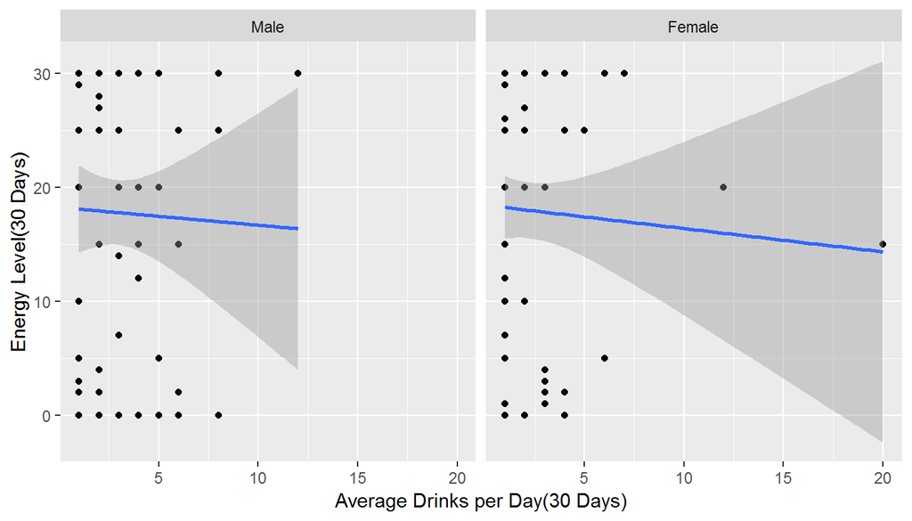

```r
ggplot(data=res2,aes(x=avedrnk2,y=qlhlth2))+geom_point()+geom_smooth(method=lm)+facet_grid(. ~sex)+xlab("Average Drinks per Day(30 Days)")+ylab("Energy Level(30 Days)")
```

Both genders are behaving similarly in the observation that there is a gradual decrease in the number of Days the respondent has full Energy with the increase in average Number of Drinks in the last 30 Days. Moreover, the Maximum number of average drinks is higher for females than males in the last 30 days.

**Research Question 3 :**

```r
res3<-brfss2013 %>% select(fvgreen,poorhlth,sex) %>% filter(!is.na(fvgreen),!is.na(poorhlth),!is.na(sex))
```

```r
res3 %>% group_by(poorhlth) %>% summary(count=n())
```

```
##     fvgreen         poorhlth          sex
##  Min.   :  0.0   Min.   : 0.000   Male  : 84866
##  1st Qu.:103.0   1st Qu.: 0.000   Female:147463
##  Median :204.0   Median : 0.000
##  Mean   :211.2   Mean   : 5.237
##  3rd Qu.:305.0   3rd Qu.: 5.000
##  Max.   :399.0   Max.   :30.000
```

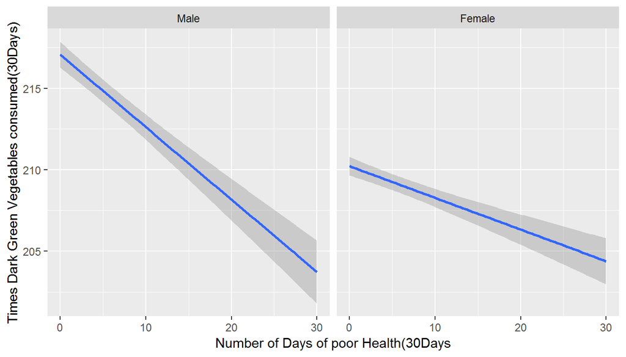

```r
ggplot(data=res3,aes(x=poorhlth,y=fvgreen))+geom_smooth(method="lm")+facet_grid(.~sex)+xlab("Number of Days of poor Health(30Days")+ylab("Times Dark Green Vegetables consumed(30Days)")
```